# Generalized Linear Models with `ciTools`

John Haman

November 2, 2017

```r
library(tidyverse)
```

```r
library(ciTools)
```

```r
library(MASS)
```

```r
library(arm)
set.seed(20171102)
```

In this vignette we will discuss the current ability of `ciTools` to handle generalized linear models. Small simulations will be provided in addition to examples that show how to use `ciTools` to quantify uncertainty in a GLM. Primarily we focus on the Logistic and Poisson models, but `ciTools`’s method for handling GLMs is not limited to these models. Note that the *Logistic-Binomial* model is handled in a separate vignette.

## The Generalized Linear Model

Generalized linear models are an extension of linear models that seek to accomodate certain types of non-linear relationships. The manner in which the non-linear relationship is addressed also allows users to perform inferences on data that are not strictly continuous. GLMs are the most common model type that allow for a non-linear relationship between the response variable $y$ and covariates $X$. Recall that linear regression directly predicts a continuous response from the linear predictor $X \beta$. A GLM extends this linear prediction scheme through the following components:

1. A response vector $y = (y_1, \ldots, y_n)$.
2. A linear predictor $X \beta$
3. A monotonic and everywhere differentiable link function $g$, which transforms the linear predictor: $\hat{y} = g^{-1}(X \hat{\beta})$.
4. A response distribution: $f(y|\mu)$ from the exponential family with expected value $\mu = g^{-1} (X \beta)$.

Other components, such as over dispersion parameters and off-set terms are possible, but not common to all GLMs. The most common GLMs in practice are the Logistic model (Bernoulli response with logit link) and the Poisson model with log-link. These are detailed below for convenience.

1. Logistic Regression:
   $$\begin{equation}
   \begin{split}
   & y|X \sim \mathrm{Binomial}(1, p) \\
   & g(p) = \log \left( \frac{p}{1-p} \right) = X\beta \\
   & \mathbb{E}[y|X] = p = \frac{\exp(X \beta)}{ 1 + \exp(X \beta)}
   \end{split}
   \end{equation}$$
2. Poisson Regression with the $\log$ link function:
   $$\begin{equation}
   \begin{split}
   & y|X \sim \mathrm{Poisson}(\lambda) \\
   & g(\lambda) = \log \left( \lambda \right) = X\beta \\
   & \mathbb{E}[y|X] = \lambda = \exp(X \beta)
   \end{split}
   \end{equation}$$

Due to the variety of options available, fitting generalized linear models is more complicated than fitting linear models. In **R**, `glm` is the starting point for handling GLM fits, and is the currently the only model fitting function that is supported by `ciTools`. We can use `ciTools` in tendem with `glm` to fit and analyze Logistic, Poisson, Quasipoisson, Gamma and Guassian models.

# Overview of `ciTools` methods for GLMs

Unlike linear models, interval estimates pertaining to GLMs generally do not have clean parametric forms. Parametric interval estimates are available in certain cases, and where ever available, `ciTools` will choose to implement them by default. Below we detail precisely what `ciTools` is doing under the hood when one of the core functions (`add_ci`, `add_pi`, `add_probs`, `add_quantile`) is called on a GLM fit.

## Confidence Intervals

For any model fit by `glm`, `add_ci()` may compute confidence intervals for predictions using either a parametric method or a bootstrap. The parametric confidence interval method computes confidence intervals of the scale of the linear predictor $X \beta$ and transforms the intervals to the response level through the inverse link function $g^{-1}$. Confidence intervals on the linear predictor level are computed using a Normal distribution for Logistic and Poisson regressions and a $t$ distribution otherwise. The intervals are given by the following expressions:

$$\begin{equation}
g^{-1}\left(x'\hat{\beta} \pm z_{1 - \alpha/2}
\sqrt{\hat{\sigma}^2x'(X'X)^{-1} x}\right)
\end{equation}$$

for Binomial and Poisson GLMs or

$$\begin{equation}
\label{eq:glmci}
g^{-1}\left(x'\hat{\beta} \pm t_{1 - \alpha/2, n-p-1}
\sqrt{\hat{\sigma}^2x'(X'X)^{-1} x}\right)
\end{equation}$$

The default method is parametric and is called with `add_ci(data, fit, ...)`. This is the method we generally recommend for constructing confidence intervals for model prediction. The bootstrap method is called with `add_ci(data, fit, type = "boot", ...)` and is included mostly for making comparisons against the parametric method. There are multiple methods of bootstrap for regression models (resampling cases, resampling residuals, parametric, etc.). The bootstrap method employed by `ciTools` in `add_ci.glm()` resamples cases and iteratively refits the model to determine confidence intervals. After collecting the bootstrap replicates, a bias-corrected bootstrap confidence interval is formed.

There are several methods for computing bootstrap confidence interval, though we don’t provide options to compute all of these type of intervals in `ciTools`. BCa intervals are slightly larger than parametric intervals, but are less biased than other types of bootstrapped intervals, including percentile based intervals. We may consider adding more types of bootstrap intervals to `ciTools` in the future.

### Logistic Regression Example

For comparison, we show an example of the confidence intervals for the probability estimates of a Logistic regression model.

```r
x <- rnorm(100, mean = 5)
y <- rbinom(n = 100, size = 1, prob = invlogit(-20 + 4*x))
df <- data.frame(x = x, y = y)
fit <- glm(y ~ x, family = binomial)
```

We use `ciTools` to compute the two type of confidence intervals, then we stack the dataframes together.

```r
df1 <- add_ci(df, fit, names = c("lwr", "upr"), alpha = 0.1) %>%
    mutate(type = "parametric")

df2 <- add_ci(df, fit, type = "boot", names = c("lwr", "upr"), alpha = 0.1, nSims = 500) %>%
    mutate(type = "bootstrap")
df <- bind_rows(df1, df2)
```

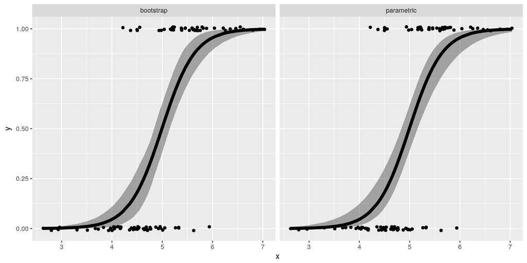

```r
ggplot(df, aes(x = x, y = y)) +
    geom_jitter(height = 0.01) +
    geom_ribbon(aes(ymin = lwr, ymax = upr), alpha = 0.4) +
    geom_line(aes(x =x , y = pred), size = 2) +
    facet_grid(~type)
```

Our two confidence interval methods mostly agree, although the bootstrap method produces interval estimates that have more variability.

```r
df3 <- filter(df, type == "parametric")

df4 <- filter(df, type == "bootstrap") %>%
    rename(lboot = lwr, uboot = upr) %>%
    bind_cols(df3)
```

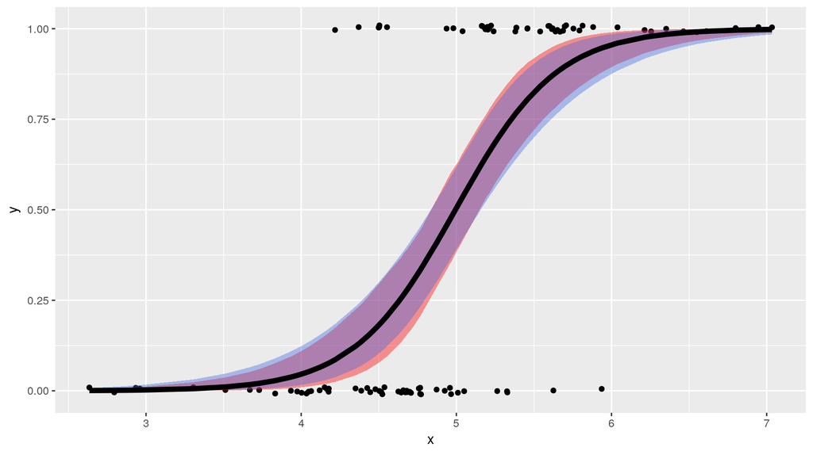

```r
ggplot(df4, aes(x = x, y = y)) +
    geom_jitter(height = 0.01) +
    geom_ribbon(aes(ymin = lboot, ymax = uboot), alpha = 0.4, fill = "red") +
    geom_ribbon(aes(ymin = lwr, ymax = upr), alpha = 0.4, fill = "royalblue") +
    geom_line(aes(x = x , y = pred), size = 2)
```

If the sample increases, we will find that the two estimates increasingly agree and converge to $0$ in width. Note that we do not calculate prediction intervals for $y$ because the support of $y$ is exactly $\{0,1\}$.

## Prediction Intervals

Generally, parametric prediction intervals for GLMs are not available. The solution `ciTools` takes is to perform a parametric bootstrap on the model fit, then take quantiles on the bootstrapped data produced for each observation. The procedure is performed via `arm::sim`. The method of the parametric bootstrap is described by the following algorithm:

1. Fit the GLM, and collect the fitted responses. Set the number of simulations, $M$.
2. Simulate $M$ draws of the regression coefficients, $\hat{\beta}_{*}$, from $N(\hat{\beta}, \hat{\mathrm{Cov}}(\hat{\beta}))$, where $\hat{\mathrm{Cov}}(\hat{\beta}) = \hat{\sigma}^2 (X'X)^{-1}$.
3. Simulate $[y_{*}|x]$ from the response distribution with mean $g^{-1}(X \hat{\beta}_{*})$ and a variance determined by the response distribution.
4. Determine the $\alpha/2$ and $1-\alpha/2$ quantiles of the simulated response $[y_{*}|x]$ for each $x$.

This parametric bootstrap method propagates the uncertainty in the regression effects $\hat{\beta}$ into the simulated draws from the predictive distribution.

Generally, there are many different ways to calculate the quantiles of an empirical distribution, but the approach that `ciTools` takes ensures that estimates quantiles lie in the support set of the response. The choice we make corresponds to the `type = 1` argument of `quantile()`.

We have seen in our simulations that the parametric bootstrap provides (with some exception) interval estimates with approximately nominal probability coverage. The unfortunate side effect of opting to construct prediction intervals through a parametric bootstrap is that the parameters of the predictive distributions need to hard coded for each model. At this point, the only models that we support with `add_pi()` are Guassian, Poisson, Binomial, Gamma, and Quasipoisson (all of which need to be fit with `glm()`).

One exception to this scheme are GLMs with Gaussian errors. In this case we may parametrically calculate prediction intervals. Under Gaussian errors, `glm()` permits the use of the link functions “identity”, “log”, and “inverse”. The corresponding models are given by the following:

$$\begin{equation}
\label{eq:gauss-link}
\begin{split}
y = X\beta + \epsilon\\
y = \exp(X\beta) + \epsilon \\
y = \frac{1}{X\beta} + \epsilon
\end{split}
\end{equation}$$

The conditional response distribution in each case may be written $y \sim N(g^{-1}(X\beta), \sigma^2)$, and prediction intervals may be computed parametrically. Parametric prediction intervals are therefore constructed via

$$\begin{equation}
\label{eq:gauss-pi}
g^{-1}(x'\beta) \pm t_{1-\alpha/2, n-p-1} \sqrt{\hat{\sigma}^2 +
\hat{\sigma}^2x'(X'X)^{-1}x}
\end{equation}$$

for Gaussian GLMs. As in the linear model, $\hat{\sigma}^2$ estimates the predictive uncertainty and $\hat{\sigma}^2 x(X'X)^{-1}x$ estimates the inferential uncertainty in the fitted values. Note that $g^{-1}(X \hat{\beta})$ is a maximum likelihood estimate for the parameter $g^{-1}(X \beta)$, by the functional invariance of maximum likelihood estimation.

## Poisson Example

Poisson regression is usually the first line of defense against count data, so we wish to present a complete example of quantifying uncertainty for this type of model with `ciTools`. For simplicity we fit a model on fake data.

We use `rnorm` to generate a covariate, but the randomness of $x$ has no bearing on the model.

```r
x <- rnorm(100, mean = 0)
y <- rpois(n = 100, lambda = exp(1.5 + 0.5*x))

df <- data.frame(x = x, y = y)
fit <- glm(y ~ x , family = poisson(link = "log"))
```

As seen previously, the commands in `ciTools` are “pipeable”. Here, we compute confidence and prediction intervals for a model fit at the level of $90\%$. The warning message only serves to remind the user that precise quantiles cannot be formed for non-continuous distributions.

```r
df_ints <- df %>%
    add_ci(fit, names = c("lcb", "ucb"), alpha = 0.1) %>%
    add_pi(fit, names = c("lpb", "upb"), alpha = 0.1, nSims = 5000) %>%
    print()
```

```
## Warning in add_pi.glm(., fit, names = c("lpb", "upb"), alpha = 0.1, nSims
## = 5000): The response is not continuous, so Prediction Intervals are
## approximate
```

```
## # A tibble: 100 x 7
##             x     y      pred       lcb       ucb   lpb   upb
##         <dbl> <int>     <dbl>     <dbl>     <dbl> <dbl> <dbl>
##  1 -2.0519678     2  1.841790  1.512871  2.242220     0     4
##  2 -1.3503557     7  2.579160  2.217452  2.999868     0     5
##  3  0.3743030     2  5.901355  5.502938  6.328618     2    10
##  4  0.4393664     6  6.088538  5.681194  6.525089     2    10
##  5  0.2497295     2  5.558872  5.172883  5.973663     2    10
##  6  2.2621171    18 14.602662 12.696356 16.795192     8    22
##  7  0.7149323    10  6.949438  6.480422  7.452399     3    12
##  8  0.4745805     8  6.192311  5.779338  6.634794     2    11
##  9  1.8237586     7 11.832166 10.558956 13.258901     6    18
## 10 -1.4035391     1  2.514161  2.154300  2.934134     0     5
## # ... with 90 more rows
```

As with other methods available in `ciTools` the requested statistics are computed, appended to the data frame, and returned to the user as a tibble.

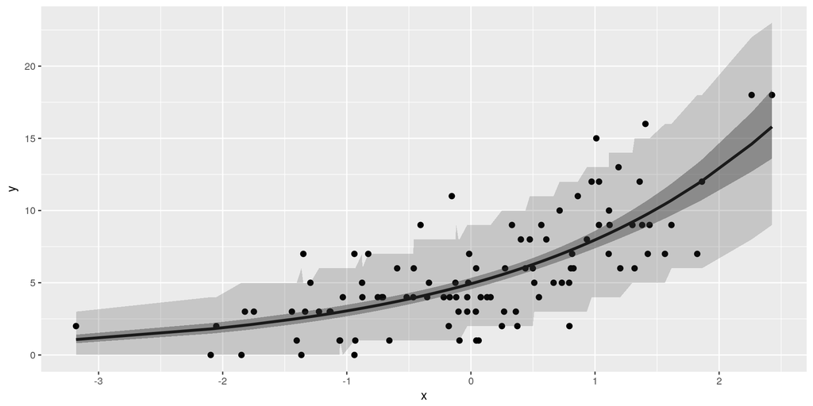

```r
df_ints %>%
    ggplot(aes(x = x, y = y)) +
    geom_point(size = 2) +
    geom_line(aes(x = x, y = pred), size = 1.2) +
    geom_ribbon(aes(ymin = lcb, ymax = ucb), alpha = 0.4) +
    geom_ribbon(aes(ymin = lpb, ymax = upb), alpha = 0.2)
```

Since the response $y$ is count data, and the method we used to determine the intervals involves simulation, we find that `ciTools` will produce “jagged” bounds when all the intervals are plotted simultaneously.

We may also wish to compute response level probabilities and quantiles. `ciTools` can also handle these estimates with `add_probs()` and `add_quantile()` respectively. Since these statistics are formed on the predictive distribution constructed by `add_pi()`, we also estimates quantiles and probabilities using the parametric bootstrap.

```r
df %>%
    add_probs(fit, q = 10) %>%
    add_quantile(fit, p = 0.4) %>%
    print()
```

```
## # A tibble: 100 x 5
##             x     y      pred prob_less_than10 quantile0.4
##         <dbl> <int>     <dbl>            <dbl>       <dbl>
##  1 -2.0519678     2  1.841790           1.0000           1
##  2 -1.3503557     7  2.579160           1.0000           2
##  3  0.3743030     2  5.901355           0.9180           5
##  4  0.4393664     6  6.088538           0.9170           5
##  5  0.2497295     2  5.558872           0.9400           5
##  6  2.2621171    18 14.602662           0.0940          14
##  7  0.7149323    10  6.949438           0.8420           6
##  8  0.4745805     8  6.192311           0.8985           5
##  9  1.8237586     7 11.832166           0.2615          11
## 10 -1.4035391     1  2.514161           0.9995           2
## # ... with 90 more rows
```

### Extension to Quasipoisson

A common problem with this model is the presence of over-dispersion. Recall that for the Poisson model, we require that the variance and mean agree, however this is practically a strict and unreasonable modeling assumption. A quasipoisson model is one remedy: it estimates an additional dispersion parameter and will provide a better fit. Under quasipoisson assumption

$$\mathbb{E}[y|X] = \mu = \exp (X \beta)$$

and

$$\mathbb{V}\mathrm{ar}[y|X] = \phi \mu$$

Quasi models are not full maximum likelihood models, however it is possible to embed a Quasipoisson in the Negative Binomial framework using

$$\mathrm{QP}(\mu, \theta) = \mathrm{NegBin}(\mu, \theta = \frac{\mu}{\phi - 1})$$

Where NegBin is the parameterization of the Negative Binomial distribution used by `glm.nb` in the `MASS` library. This model for the negative binomial distribution, a continuous mixture of Poisson random variables with gamma distributed means, is preferred over that classical parameterization in applications. The preference stems from the fact that it allows for non-integer valued “$\theta$”.

Warning: As in Gelman and Hill’s *Data Analysis using Regression and Multilevel/Hierarchical Model*, `ciTools` does not simulate the uncertainty in the over-dispersion parameter $\hat{\phi}$. According to our simulations, dropping this unceratinty from the parametric bootstrap has a negligible effect on the coverage probabilities. While the distribution of $\hat{\phi}$ is asymptotically Normal, it is very likely that the finite sample estimator has a skewed distribution. Approximating this distribution for use in a parametric bootstrap is ongoing research. As it stands, the prediction intervals we form for over-dispersed models tend to be conservative.

Negative binomial regression (via `glm.nb`) is implemented as a separate method in `ciTools`, and is an alternative to quasipoisson regression. For more information on the difference between these two models, we recommend Jay Ver Hoef and Peter Boveng’s *Quasi-poisson vs. Negative Binomial Regression: How Should We Model Overdispersed Count Data?*

### Example

Again, we generate fake data. The dispersion parameter is set to $5$ in the negative binomial model.

```r
x <- runif(n = 100, min = 0, max = 2)
mu <- exp(1 + x)
y <- rnegbin(n = 100, mu = mu, theta = mu/(5 - 1))
```

The data is over-dispersed:

```r
df <- data.frame(x = x, y = y)
fit <- glm(y ~ x, family = quasipoisson(link = "log"))
summary(fit)$dispersion
```

```
## [1] 5.310772
```

But `ciTools` can still construct appropriate interval estimates for the range of a new observation:

```r
df_ints <- add_ci(df, fit, names = c("lcb", "ucb"), alpha = 0.05) %>%
    add_pi(fit, names = c("lpb", "upb"), alpha = 0.1, nSims = 5000)
```

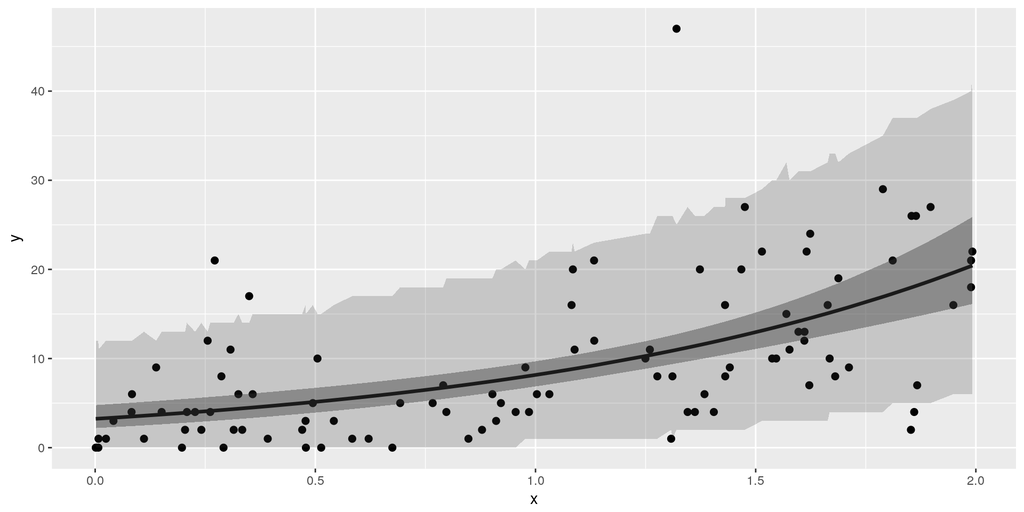

```r
ggplot(df_ints, aes(x = x, y = y)) +
    geom_point(size = 2) +
    geom_line(aes(x = x, y = pred), size = 1.2) +
    geom_ribbon(aes(ymin = lcb, ymax = ucb), alpha = 0.4) +
    geom_ribbon(aes(ymin = lpb, ymax = upb), alpha = 0.2)
```

A small simulation study was performed to examine the empirical coverage probilities of prediction intervals formed using the parametric bootstrap. We focus on these intervals as there is essentially no treatment in the literature regarding their performance, so users of `ciTools` should be more skeptical of these methods.

### Poisson

```r
pois <- read_csv("pois_pi_results.csv")

knitr::kable(pois)
```

| total_time | level | sample_size | cov_prob | cov_prob_se | int_width | int_width_se |
| --- | --- | --- | --- | --- | --- | --- |
| 7.673767 | 0.95 | 20 | 0.98 | 0.0140705 | 22.88 | 0.0867831 |
| 7.673767 | 0.95 | 30 | 0.96 | 0.0196946 | 26.37 | 0.0824560 |
| 7.673767 | 0.95 | 50 | 0.97 | 0.0171447 | 22.72 | 0.0711805 |
| 7.673767 | 0.95 | 100 | 0.94 | 0.0238683 | 41.86 | 0.0921352 |
| 7.673767 | 0.95 | 250 | 0.95 | 0.0219043 | 37.39 | 0.0941683 |
| 7.673767 | 0.95 | 500 | 0.90 | 0.0301511 | 32.08 | 0.0734159 |
| 7.673767 | 0.95 | 1000 | 0.93 | 0.0256432 | 25.68 | 0.0694568 |
| 7.673767 | 0.95 | 2000 | 0.94 | 0.0238683 | 39.44 | 0.0924635 |

### Negative Binomial

```r
neg_bin <- read_csv("negbin_pi_results.csv")

knitr::kable(neg_bin)
```

| total_time | level | sample_size | cov_prob | cov_prob_se | int_width | int_width_se |
| --- | --- | --- | --- | --- | --- | --- |
| 11.34318 | 0.95 | 26 | 0.960 | 0.0124184 | 9.880 | 0.0905494 |
| 11.34318 | 0.95 | 50 | 0.980 | 0.0088721 | 10.588 | 0.0790063 |
| 11.34318 | 0.95 | 76 | 0.940 | 0.0150501 | 15.816 | 0.1061586 |
| 11.34318 | 0.95 | 100 | 0.956 | 0.0129974 | 20.216 | 0.1367633 |
| 11.34318 | 0.95 | 126 | 0.964 | 0.0118057 | 23.532 | 0.1367579 |
| 11.34318 | 0.95 | 150 | 0.956 | 0.0129974 | 16.632 | 0.0848475 |
| 11.34318 | 0.95 | 176 | 0.972 | 0.0104547 | 7.352 | 0.0373895 |
| 11.34318 | 0.95 | 200 | 0.944 | 0.0145707 | 14.512 | 0.0570301 |

### Gamma with “inverse” link

```r
gam <- read_csv("gamma_pi_results.csv")

knitr::kable(gam)
```

| total_time | level | sample_size | cov_prob | cov_prob_se | int_width | int_width_se |
| --- | --- | --- | --- | --- | --- | --- |
| 6.232933 | 0.95 | 100 | 0.96 | 0.0196946 | 354.0841 | 3.404453 |
| 6.232933 | 0.95 | 250 | 0.95 | 0.0219043 | 338.5753 | 3.000530 |
| 6.232933 | 0.95 | 500 | 0.98 | 0.0140705 | 346.8959 | 1.464468 |
| 6.232933 | 0.95 | 1000 | 0.96 | 0.0196946 | 340.8781 | 1.445155 |
| 6.232933 | 0.95 | 2000 | 0.93 | 0.0256432 | 344.8219 | 1.053053 |

### Gaussian with log link

```r
norm_log<- read_csv("gaussian_pi_loglink_results.csv")

knitr::kable(norm_log)
```

| total_time | level | sample_size | cov_prob | cov_prob_se | int_width | int_width_se |
| --- | --- | --- | --- | --- | --- | --- |
| 0.14625 | 0.95 | 20 | 0.940 | 0.0168350 | 4.157730 | 0.0490361 |
| 0.14625 | 0.95 | 30 | 0.930 | 0.0180869 | 4.022809 | 0.0400538 |
| 0.14625 | 0.95 | 50 | 0.930 | 0.0180869 | 4.085885 | 0.0282862 |
| 0.14625 | 0.95 | 100 | 0.950 | 0.0154497 | 3.936784 | 0.0206400 |
| 0.14625 | 0.95 | 250 | 0.940 | 0.0168350 | 3.944355 | 0.0130057 |
| 0.14625 | 0.95 | 500 | 0.955 | 0.0146954 | 3.930217 | 0.0088687 |
| 0.14625 | 0.95 | 1000 | 0.935 | 0.0174758 | 3.916335 | 0.0055721 |
| 0.14625 | 0.95 | 2000 | 0.955 | 0.0146954 | 3.927517 | 0.0041762 |